# Reproducible Research Project 1

## Loading and processing the data

Loading the data into R and summarizing the dataset:

```r
activityData <- read.csv("activity.csv", header = T)
summary(activityData)
```

```
##      steps                date          interval
##  Min.   :  0.00   2012-10-01:  288   Min.   :   0.0
##  1st Qu.:  0.00   2012-10-02:  288   1st Qu.: 588.8
##  Median :  0.00   2012-10-03:  288   Median :1177.5
##  Mean   : 37.38   2012-10-04:  288   Mean   :1177.5
##  3rd Qu.: 12.00   2012-10-05:  288   3rd Qu.:1766.2
##  Max.   :806.00   2012-10-06:  288   Max.   :2355.0
##  NA's   :2304     (Other)   :15840
```

The dataset appears to be tidy and therefore I will not perform any transformations to the dataset.

## What is the mean total number of steps taken each day?

Calculating the total number of steps taken per day:

```r
stepsData <- aggregate(steps ~ date, activityData, sum)
stepsData
```

```
##          date steps
## 1  2012-10-02   126
## 2  2012-10-03 11352
## 3  2012-10-04 12116
## 4  2012-10-05 13294
## 5  2012-10-06 15420
## 6  2012-10-07 11015
## 7  2012-10-09 12811
## 8  2012-10-10  9900
## 9  2012-10-11 10304
## 10 2012-10-12 17382
## 11 2012-10-13 12426
## 12 2012-10-14 15098
## 13 2012-10-15 10139
## 14 2012-10-16 15084
```

[output cut: 39 more lines]

Plotting a histogram of the total number of steps taken per day:

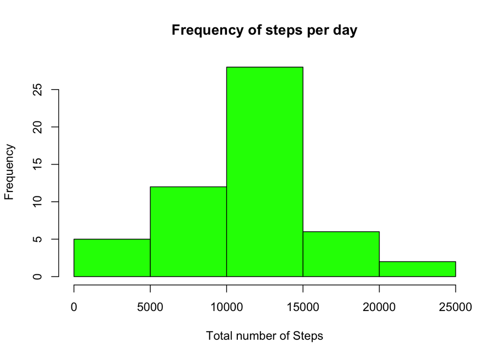

```r
hist(stepsData$steps, main = "Frequency of steps per day", xlab = "Total number of Steps", ylab = "Frequency", col = "green")
```

```r
stepsDataMean <- aggregate(steps ~ date, activityData, mean, na.rm = TRUE)
stepsDataMean
```

```
##          date      steps
## 1  2012-10-02  0.4375000
## 2  2012-10-03 39.4166667
## 3  2012-10-04 42.0694444
## 4  2012-10-05 46.1597222
## 5  2012-10-06 53.5416667
## 6  2012-10-07 38.2465278
## 7  2012-10-09 44.4826389
## 8  2012-10-10 34.3750000
## 9  2012-10-11 35.7777778
## 10 2012-10-12 60.3541667
## 11 2012-10-13 43.1458333
## 12 2012-10-14 52.4236111
## 13 2012-10-15 35.2048611
## 14 2012-10-16 52.3750000
```

[output cut: 39 more lines]

```r
stepsDataMedian <- aggregate(steps ~ date, activityData, median, na.rm = TRUE)
stepsDataMedian
```

```
##          date steps
## 1  2012-10-02     0
## 2  2012-10-03     0
## 3  2012-10-04     0
## 4  2012-10-05     0
## 5  2012-10-06     0
## 6  2012-10-07     0
## 7  2012-10-09     0
## 8  2012-10-10     0
## 9  2012-10-11     0
## 10 2012-10-12     0
## 11 2012-10-13     0
## 12 2012-10-14     0
## 13 2012-10-15     0
## 14 2012-10-16     0
```

[output cut: 39 more lines]

## What is the average daily activity pattern?

Creating a time series plot of the 5-minute interval and the average number of steps taken, averaged across all days:

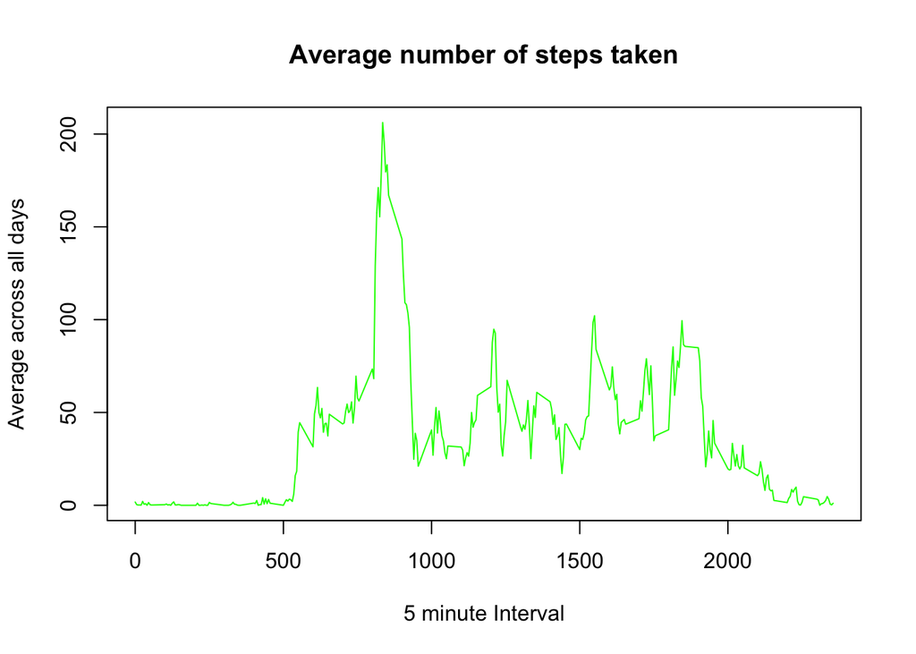

```r
timeSeries <- tapply(activityData$steps, activityData$interval, mean, na.rm = TRUE)
plot(row.names(timeSeries), timeSeries, type = "l", main = "Average number of steps taken", xlab = "5 minute Interval", ylab = "Average across all days", col = "green")
```

Which 5th-minute interval, on average across all the days in the dataset, contains the maximum number of steps?

```r
maxSteps <- which.max(timeSeries)
names(maxSteps)
```

```
## [1] "835"
```